# R Notebook: IMDB (advanced features) for Will v Denzel

```r
library(devtools);
library(humanVerseWSU);

path.github = "https://raw.githubusercontent.com/MonteShaffer/humanVerseWSU/master/";

include.me = paste0(path.github, "misc/functions-nlp.R");
source_url( include.me );
```

```
## SHA-1 hash of file is d411302cf0069ed51cc5dfb8c1163a7869329eed
```

```r
include.me = paste0(path.github, "misc/functions-nlp-str.R");
source_url( include.me );
```

```
## SHA-1 hash of file is 54604c6aba08045f7965d86773bf15d7288a67fe
```

```r
include.me = paste0(path.github, "misc/functions-nlp-stack.R");
source_url( include.me );
```

```
## SHA-1 hash of file is fb9b84a774f8d46c97db92eabfc7ae778b49cfeb
```

```r
include.me = paste0(path.github, "misc/functions-nlp-pos.R");
source_url( include.me );
```

```
## SHA-1 hash of file is c4185150c8c43a59e88093872bef9c0fb4bc1dc5
```

```r
include.me = paste0(path.github, "humanVerseWSU/R/functions-encryption.R");
source_url( include.me );
```

```
## SHA-1 hash of file is da71dde620bed33db055778b752eefb476f7bf6b
```

```r
path.to.nascent = "C:/Users/Alexander Nevsky/Dropbox/WSU-419/Fall 2020/__student_access__/unit_02_confirmatory_data_analysis/nascent/";

folder.nlp = "nlp/";
path.to.nlp = paste0(path.to.nascent, folder.nlp);


###### UPDATES TO dataframe subset function ######
# inflation adjustments for NA ... and improvements on subsetting
include.me = paste0(path.github, "humanVerseWSU/R/functions-dataframe.R");
source_url( include.me );
```

```
## SHA-1 hash of file is 1149cbf3e865f692b50d4d1983e6364dc56ce62d
```

```r
include.me = paste0(path.github, "humanVerseWSU/R/functions-inflation.R");
source_url( include.me );
```

```
## SHA-1 hash of file is b6d29327e3fe030ca132b135f4a89b6fc6a61a66
```

# 1 (IMDB) Custom library

This is a large dataset I harvested in September. It will allow us to explore more comprehensively the relationships of various features of the movie database. It is large (about 50MB), so installing may take some time if you are on a slow internet connection.

This dataset will be the source you will use on your final exam to answer the question posed earlier in the semester about Will Smith and Denzel Washington. You now have more analytics skills and with the new dataset there are more features you can extract.

```r
# library(devtools);
# install_github("MonteShaffer/imdb/imdb"); # choose #3 to humanVerseWSU
# detach(package:imdb);
library(imdb);
packageVersion("imdb");  # ‘0.1.1’
```

```
## [1] '0.1.1'
```

```r
# ?loadDataIMDB
```

## 1.1 Load data

Once this is run, a lot of memory will be required to read in the 23 compressed files.

```r
imdb::loadDataIMDB();
names(imdb.data);
```

```
##  [1] "all.movies.creatives"         "all.movies.companies"
##  [3] "all.movies.actors.characters" "all.actors.rank"
##  [5] "all.actors.movies"            "all.actors.info"
##  [7] "moviecount.byyear"            "actors"
##  [9] "glue"                         "headliners"
## [11] "movies"                       "movies.df"
```

```r
humanVerseWSU::loadInflationData();
```

## 1.2 Will Smith cont’d

### 1.2.1 Cast

```r
will.nmid = "nm0000226";
will.movies = IMDB.getMoviesForPerson(will.nmid);
will.n = nrow(will.movies);
will.cast = merge(will.movies[,c(1,3:5)], imdb.data$movies.df$cast, by="ttid");

length(unique(will.cast$nmid));
```

```
## [1] 971
```

```r
nrow(will.cast);
```

```
## [1] 1078
```

```r
will.cast;  # this merge will create about 111 x 15
```

| ttid | rank | year | title | actor.rank | nmid | name | character |
| --- | --- | --- | --- | --- | --- | --- | --- |
| tt0105810 | 53 | 1992 | Where the Day Takes You | 2 | nm0000551 | Dermot Mulroney | King |
| tt0105810 | 53 | 1992 | Where the Day Takes You | 1 | nm0000624 | Laura San Giacomo | The Interviewer |
| tt0105810 | 53 | 1992 | Where the Day Takes You | 10 | nm0229930 | Peter Dobson | Tommy Ray |
| tt0105810 | 53 | 1992 | Where the Day Takes You | 11 | nm0001492 | Kyle MacLachlan | Ted |
| tt0105810 | 53 | 1992 | Where the Day Takes You | 12 | nm0001529 | Nancy McKeon | Vikki |
| tt0105810 | 53 | 1992 | Where the Day Takes You | 13 | nm0000284 | Adam Baldwin | Officer Black |
| tt0105810 | 53 | 1992 | Where the Day Takes You | 14 | nm0001797 | Rachel Ticotin | Officer Landers |
| tt0105810 | 53 | 1992 | Where the Day Takes You | 15 | nm0000192 | Alyssa Milano | Kimmy |
| tt0105810 | 53 | 1992 | Where the Day Takes You | 3 | nm0460694 | Robert Knepper | Rock Singer |
| tt0105810 | 53 | 1992 | Where the Day Takes You | 4 | nm0000276 | Sean Astin | Greg |

[output cut: 1068 more lines]

### 1.2.2 Cast bio

```r
will.cast.info = merge(will.cast, imdb.data$all.actors.info, by="nmid");
dim(will.cast.info);
```

```
## [1] 705  17
```

```r
will.cast.info;  # we have 705 that have a "actor.info" page ... that means they were tied to top-50 movies by year somehow
```

| nmid | ttid | rank | year | title | actor.rank | name.x | character | name.y | roles | born.when | born.where | died.when | died.where | starmeter.rank | starmeter.delta | bio |
| --- | --- | --- | --- | --- | --- | --- | --- | --- | --- | --- | --- | --- | --- | --- | --- | --- |
| nm0000110 | tt0120891 | 24 | 1999 | Wild Wild West | 3 | Kenneth Branagh | Dr. Arliss Loveless | Kenneth Branagh | Actor,Producer,Director | 1960-12-10 | Belfast, Northern Ireland, UK | NA | NA | 500 | -109 | Kenneth Charles Branagh was born on December 10, 1960, in Belfast, Northern Ireland, to parents William Branagh, a plumber and carpenter, and Frances (Harper), both born in 1930. He has two siblings, … |
| nm0000120 | tt0205314 | 72 | 1998 | Pesel Ha'Zahav | 4 | Jim Carrey | Self | Jim Carrey | Actor,Writer,Producer | 1962-1-17 | Newmarket, Ontario, Canada | NA | NA | 500 | -37 | Jim Carrey, Canadian-born and a U.S. citizen since 2004, is an actor and producer famous for his rubbery body movements and flexible facial expressions. The two-time Golden Globe-winner rose to fame a… |
| nm0000128 | tt1837709 | 35 | 2014 | Winter's Tale | 8 | Russell Crowe | Pearly Soames | Russell Crowe | Actor,Soundtrack,Producer | 1964-4-7 | Wellington, New Zealand | NA | NA | 500 | -119 | Russell Ira Crowe was born in Wellington, New Zealand, to Jocelyn Yvonne (Wemyss) and John Alexander Crowe, both of whom catered movie sets. His maternal grandfather, Stanley Wemyss, was a cinematogra… |
| nm0000134 | tt0307453 | 22 | 2004 | Shark Tale | 2 | Robert De Niro | Don Lino (voice) | Robert De Niro | Actor,Producer,Soundtrack | 1943-8-17 | New York City, New York, USA | NA | NA | 500 | 4 | One of the greatest actors of all time, Robert De Niro was born on August 17, 1943 in Manhattan, New York City, to artists Virginia (Admiral) and Robert De Niro Sr. His paternal grandfather was of Ita… |
| nm0000134 | tt0284490 | 33 | 2002 | Showtime | 1 | Robert De Niro | Det. Mitch Preston | Robert De Niro | Actor,Producer,Soundtrack | 1943-8-17 | New York City, New York, USA | NA | NA | 500 | 4 | One of the greatest actors of all time, Robert De Niro was born on August 17, 1943 in Manhattan, New York City, to artists Virginia (Admiral) and Robert De Niro Sr. His paternal grandfather was of Ita… |
| nm0000137 | tt0328099 | 45 | 2003 | Malibu's Most Wanted | 8 | Bo Derek | Bess Gluckman | Bo Derek | Actress,Producer,Camera and Electrical Department | 1956-11-20 | Long Beach, California, USA | NA | NA | 5000 | 423 | Bo Derek was born on November 20, 1956 in Long Beach, California, USA as Mary Cathleen Collins. She is an actress and producer, known for Bolero (1984), Ghosts Can't Do It (1989) and Tommy Boy (1995).… |
| nm0000139 | tt1823664 | 38 | 2014 | Annie | 7 | Cameron Diaz | Hannigan | Cameron Diaz | Actress,Producer,Soundtrack | 1972-8-30 | San Diego, California, USA | NA | NA | 5000 | -118 | A tall, strikingly attractive blue-eyed natural blonde, Cameron Diaz was born in 1972 in San Diego, the daughter of a Cuban-American father and a German mother. Self described as "adventurous, indepen… |
| nm0000146 | tt0114558 | 31 | 1995 | Strange Days | 1 | Ralph Fiennes | Lenny Nero | Ralph Fiennes | Actor,Director,Producer | 1962-12-22 | Ipswich, Suffolk, England, UK | NA | NA | 500 | 129 | Actor Ralph Nathaniel Twisleton-Wykeham-Fiennes was born on December 22, 1962 in Suffolk, England, to Jennifer Anne Mary Alleyne (Lash), a novelist, and Mark Fiennes, a photographer. He is the eldest … |
| nm0000148 | tt1229340 | 20 | 2013 | Anchorman 2: The Legend Continues | 15 | Harrison Ford | Mack Tannen | Harrison Ford | Actor,Writer,Producer | 1942-7-13 | Chicago, Illinois, USA | NA | NA | 500 | -7 | Harrison Ford was born on July 13, 1942 in Chicago, Illinois, to Dorothy (Nidelman), a radio actress, and Christopher Ford (born John William Ford), an actor turned advertising executive. His father w… |
| nm0000155 | tt0107478 | 48 | 1993 | Made in America | 1 | Whoopi Goldberg | Sarah Mathews | Whoopi Goldberg | Actress,Producer,Writer | 1955-11-13 | New York City, New York, USA | NA | NA | 5000 | 228 | Whoopi Goldberg was born Caryn Elaine Johnson in the Chelsea section of Manhattan on November 13, 1955. Her mother, Emma (Harris), was a teacher and a nurse, and her father, Robert James Johnson, Jr.,… |

[output cut: 695 more lines]

```r
# let's predict gender
predictGenderFromBio = function(bio, gender = list(
            "male" = c("he", "his", "him"),
          "female" = c("she", "hers", "her")) )
  {
  bio = gsub("(","",bio,fixed=TRUE);
  bio = gsub(")","",bio,fixed=TRUE);
  bio = gsub('"',"",bio,fixed=TRUE);

  words = getRawWords(bio); # from nlp, converts to lower

  mycounts = list("male" = 0, "female" = 0);
  tc = 0;
  gc = 2;
  for(i in 1:gc)
    {
    key = names(gender)[i];
    for(j in 1:length(gender[[key]]))
      {
      mc = sum(words == gender[[key]][j]);
      mycounts[[key]] = mc + mycounts[[key]];
      tc = mc + tc;
      }
    }
  # mycounts;
  # we could return a ratio ... but a decision for this example would likely be best ...
  if(tc == 0) { return (NA); } # no data ...
  result = "male"; # default in hollywood?
  if(mycounts$female > mycounts$male) { result = "female"; }
  result;
  }
```

### 1.2.3 Cast gender

```r
will.cast.info$gender = NA;
for(i in 1:nrow(will.cast.info))
  {
  will.cast.info$gender[i] = predictGenderFromBio(will.cast.info$bio[i]);
  }

table(will.cast.info$gender);
```

```
##
## female   male
##    190    447
```

```r
# we could cleanup NA using first name ... maybe ... Cameron Diaz is NA?
```

### 1.2.4 Cast by year

```r
table(will.cast.info$year);
```

```
##
## 1992 1993 1995 1996 1997 1998 1999 2000 2001 2002 2003 2004 2005 2006 2007 2008
##   15   18   29   15   15   44   37   11   22   24   40   57   21   18   32   60
## 2009 2010 2012 2013 2014 2015 2016 2017 2018 2019 2020 2021
##   20   24   24   20   18   27   25   11   15   36   14    7
```

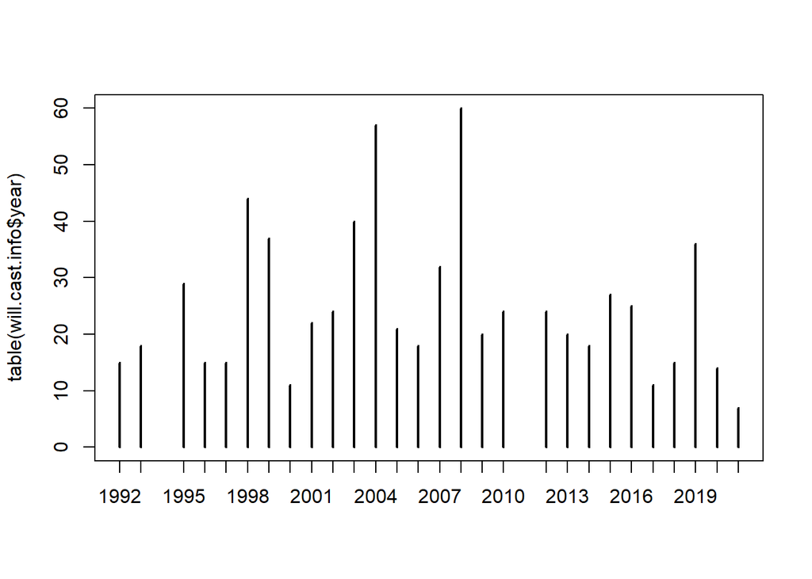

```r
plot( table(will.cast.info$year) );  # unique collaborators each year ... basically 15 * number of movies ...
```

### 1.2.5 Cast gender, by year

```r
# could "genderify" using a grouping ... is there a trend in the gender collaboration thing?  Was there a change point?
will.cast.info$gender = factor(will.cast.info$gender)
# https://www.datasciencemadesimple.com/table-function-in-r/
#prop.table( as.table(table(will.cast.info$year,will.cast.info$gender)) );
byyear = as.numeric(table(will.cast.info$year));
table(will.cast.info$year,will.cast.info$gender)/byyear;  # NA on gender may make this a bit off from 100%
```

```
##
##            female       male
##   1992 0.33333333 0.46666667
##   1993 0.38888889 0.61111111
##   1995 0.17241379 0.68965517
##   1996 0.26666667 0.73333333
##   1997 0.13333333 0.86666667
##   1998 0.38636364 0.59090909
##   1999 0.35135135 0.54054054
##   2000 0.09090909 0.81818182
##   2001 0.27272727 0.72727273
##   2002 0.16666667 0.62500000
##   2003 0.22500000 0.67500000
##   2004 0.28070175 0.63157895
##   2005 0.38095238 0.57142857
##   2006 0.22222222 0.55555556
##   2007 0.28125000 0.46875000
##   2008 0.40000000 0.51666667
##   2009 0.30000000 0.70000000
##   2010 0.08333333 0.70833333
##   2012 0.33333333 0.58333333
##   2013 0.20000000 0.75000000
##   2014 0.22222222 0.61111111
##   2015 0.07407407 0.85185185
##   2016 0.36000000 0.60000000
##   2017 0.27272727 0.72727273
##   2018 0.46666667 0.46666667
##   2019 0.16666667 0.63888889
##   2020 0.28571429 0.71428571
##   2021 0.14285714 0.71428571
```

### 1.2.6 Cast changing name

```r
new.name = which(will.cast.info$name.x != will.cast.info$name.y);
will.cast.info[new.name,];
```

|  | nmid | ttid | rank | year | title | actor.rank | name.x | character | name.y | roles | born.when | born.where | died.when | died.where | starmeter.rank | starmeter.delta | bio | gender |
| --- | --- | --- | --- | --- | --- | --- | --- | --- | --- | --- | --- | --- | --- | --- | --- | --- | --- | --- |
| 277 | nm0008867 | tt1383607 | 56 | 2008 | Ramadan Mabrouk Abul-Alamein Hamouda | 3 | Izzat Abu-Of | Minister of Education (as Ezzat Abou Aouf) | Ezzat Abu Auf | Actor,Composer | 1948-8-21 | Egypt | 2019-7-1 | Cairo, Egypt | NA | 85825 | He worked as an obstetrician, although he was interested in music. After he left his medical career, he became a musician and then later an actor both in cinema and television. | male |

### 1.2.7 Cast role diversity (not necessarily in his films)

```r
# build roles as unique columns with dataframe function

will.cast.info.r = replaceFactorColumnWithIndicatorVariables(will.cast.info, "roles", "role", use.boolean=FALSE);

will.cast.info.r;
```

| nmid | ttid | rank | year | title | actor.rank | name.x | character | name.y | roles | role.actor | role.actress | role.art department | role.camera and electrical department | role.casting department | role.casting director | role.cinematographer | role.composer | role.costume and wardrobe department | role.costume designer | role.director | role.editor | role.location management | role.miscellaneous crew | role.music department | role.producer | role.second unit director or assistant director | role.sound department | role.soundtrack | role.special effects | … |
| --- | --- | --- | --- | --- | --- | --- | --- | --- | --- | --- | --- | --- | --- | --- | --- | --- | --- | --- | --- | --- | --- | --- | --- | --- | --- | --- | --- | --- | --- | --- |
| nm0000110 | tt0120891 | 24 | 1999 | Wild Wild West | 3 | Kenneth Branagh | Dr. Arliss Loveless | Kenneth Branagh | Actor,Producer,Director | 1 | 0 | 0 | 0 | 0 | 0 | 0 | 0 | 0 | 0 | 1 | 0 | 0 | 0 | 0 | 1 | 0 | 0 | 0 | 0 | … |
| nm0000120 | tt0205314 | 72 | 1998 | Pesel Ha'Zahav | 4 | Jim Carrey | Self | Jim Carrey | Actor,Writer,Producer | 1 | 0 | 0 | 0 | 0 | 0 | 0 | 0 | 0 | 0 | 0 | 0 | 0 | 0 | 0 | 1 | 0 | 0 | 0 | 0 | … |
| nm0000128 | tt1837709 | 35 | 2014 | Winter's Tale | 8 | Russell Crowe | Pearly Soames | Russell Crowe | Actor,Soundtrack,Producer | 1 | 0 | 0 | 0 | 0 | 0 | 0 | 0 | 0 | 0 | 0 | 0 | 0 | 0 | 0 | 1 | 0 | 0 | 1 | 0 | … |
| nm0000134 | tt0307453 | 22 | 2004 | Shark Tale | 2 | Robert De Niro | Don Lino (voice) | Robert De Niro | Actor,Producer,Soundtrack | 1 | 0 | 0 | 0 | 0 | 0 | 0 | 0 | 0 | 0 | 0 | 0 | 0 | 0 | 0 | 1 | 0 | 0 | 1 | 0 | … |
| nm0000134 | tt0284490 | 33 | 2002 | Showtime | 1 | Robert De Niro | Det. Mitch Preston | Robert De Niro | Actor,Producer,Soundtrack | 1 | 0 | 0 | 0 | 0 | 0 | 0 | 0 | 0 | 0 | 0 | 0 | 0 | 0 | 0 | 1 | 0 | 0 | 1 | 0 | … |
| nm0000137 | tt0328099 | 45 | 2003 | Malibu's Most Wanted | 8 | Bo Derek | Bess Gluckman | Bo Derek | Actress,Producer,Camera and Electrical Department | 0 | 1 | 0 | 1 | 0 | 0 | 0 | 0 | 0 | 0 | 0 | 0 | 0 | 0 | 0 | 1 | 0 | 0 | 0 | 0 | … |
| nm0000139 | tt1823664 | 38 | 2014 | Annie | 7 | Cameron Diaz | Hannigan | Cameron Diaz | Actress,Producer,Soundtrack | 0 | 1 | 0 | 0 | 0 | 0 | 0 | 0 | 0 | 0 | 0 | 0 | 0 | 0 | 0 | 1 | 0 | 0 | 1 | 0 | … |
| nm0000146 | tt0114558 | 31 | 1995 | Strange Days | 1 | Ralph Fiennes | Lenny Nero | Ralph Fiennes | Actor,Director,Producer | 1 | 0 | 0 | 0 | 0 | 0 | 0 | 0 | 0 | 0 | 1 | 0 | 0 | 0 | 0 | 1 | 0 | 0 | 0 | 0 | … |
| nm0000148 | tt1229340 | 20 | 2013 | Anchorman 2: The Legend Continues | 15 | Harrison Ford | Mack Tannen | Harrison Ford | Actor,Writer,Producer | 1 | 0 | 0 | 0 | 0 | 0 | 0 | 0 | 0 | 0 | 0 | 0 | 0 | 0 | 0 | 1 | 0 | 0 | 0 | 0 | … |
| nm0000155 | tt0107478 | 48 | 1993 | Made in America | 1 | Whoopi Goldberg | Sarah Mathews | Whoopi Goldberg | Actress,Producer,Writer | 0 | 1 | 0 | 0 | 0 | 0 | 0 | 0 | 0 | 0 | 0 | 0 | 0 | 0 | 0 | 1 | 0 | 0 | 0 | 0 | … |

[output cut: 695 more lines]

### 1.2.8 Cast proportions of diversity

```r
n.will.r = length(unique(will.cast.info.r$ttid));  # of 111 n.will, how many are in this merged dataframe

# 11:34 ... total roles ... a single nmid may have up to 3 roles ... this is not necessarily the role of the nmid working with Will, but nmid diversity
length(names(will.cast.info.r[11:34]));
```

```
## [1] 24
```

```r
# colSums(will.cast.info.r[,11:34]);
role.p = sort(colSums(will.cast.info.r[,11:34])/n.will.r, decreasing = TRUE);  # proportion by movie
role.p;
```

```
##                                      role.actor
##                                      6.47368421
##                                   role.producer
##                                      5.11842105
##                                 role.soundtrack
##                                      3.46052632
##                                    role.actress
##                                      2.72368421
##                                     role.writer
##                                      2.14473684
##                                   role.director
##                                      1.48684211
##                           role.music department
##                                      0.76315789
##                         role.miscellaneous crew
##                                      0.47368421
##                                     role.stunts
##                                      0.31578947
##                                   role.composer
##                                      0.21052632
##           role.camera and electrical department
##                                      0.09210526
##                             role.visual effects
##                                      0.06578947
##                             role.art department
##                                      0.03947368
##                                     role.editor
##                                      0.03947368
## role.second unit director or assistant director
##                                      0.03947368
##                         role.casting department
##                                      0.02631579
##                           role.casting director
##                                      0.02631579
##                        role.location management
##                                      0.02631579
##                           role.sound department
##                                      0.02631579
##                            role.cinematographer
##                                      0.01315789
##            role.costume and wardrobe department
##                                      0.01315789
##                           role.costume designer
##                                      0.01315789
##                            role.special effects
##                                      0.01315789
##                  role.transportation department
##                                      0.01315789
```

```r
#could "group by" gender
```

### 1.2.9 HHI Diversity Index

https://en.wikipedia.org/wiki/Herfindahl%E2%80%93Hirschman_Index

Likely a nature of Hollywood Structure.

```r
# How diverse is this?
topN = 6;
H = sum(role.p[1:topN]^2);
N = length(role.p[1:topN]);
H.star = (H - 1/N)/ (1 - 1/N);

H;
```

```
## [1] 94.31111
```

```r
N;
```

```
## [1] 6
```

```r
H.star;
```

```
## [1] 112.9733
```

### 1.2.10 HHI of movie genre

```r
will.movies.r = replaceFactorColumnWithIndicatorVariables(will.movies, "genre", "genre", use.boolean=FALSE);
will.movies.r;  # if I did this with a larger dataframe, it would possibly pick up more categories ... 7:24
```

|  | ttid | nmid | rank | year | title | genre | genre.action | genre.adventure | genre.animation | genre.biography | genre.comedy | genre.crime | genre.documentary | genre.drama | genre.family | genre.fantasy | genre.history | genre.music | genre.musical | genre.mystery | genre.romance | genre.sci-fi | genre.sport | genre.thriller | rated | minutes | ratings | metacritic | votes | … |
| --- | --- | --- | --- | --- | --- | --- | --- | --- | --- | --- | --- | --- | --- | --- | --- | --- | --- | --- | --- | --- | --- | --- | --- | --- | --- | --- | --- | --- | --- | --- |
| 39 | tt0480249 | nm0000226 | 1 | 2007 | I Am Legend | Action, Adventure, Drama | 1 | 1 | 0 | 0 | 0 | 0 | 0 | 1 | 0 | 0 | 0 | 0 | 0 | 0 | 0 | 0 | 0 | 0 | PG-13 | 101 | 7.2 | 65 | 675160 | … |
| 65 | tt1386697 | nm0000226 | 2 | 2016 | Suicide Squad | Action, Adventure, Fantasy | 1 | 1 | 0 | 0 | 0 | 0 | 0 | 0 | 0 | 1 | 0 | 0 | 0 | 0 | 0 | 0 | 0 | 0 | PG-13 | 123 | 6.0 | 40 | 588064 | … |
| 6 | tt0116629 | nm0000226 | 3 | 1996 | Independence Day | Action, Adventure, Sci-Fi | 1 | 1 | 0 | 0 | 0 | 0 | 0 | 0 | 0 | 0 | 0 | 0 | 0 | 0 | 0 | 1 | 0 | 0 | PG-13 | 145 | 7.0 | 59 | 520592 | … |
| 7 | tt0119654 | nm0000226 | 4 | 1997 | Men in Black | Action, Adventure, Comedy | 1 | 1 | 0 | 0 | 1 | 0 | 0 | 0 | 0 | 0 | 0 | 0 | 0 | 0 | 0 | 0 | 0 | 0 | PG-13 | 98 | 7.3 | 71 | 507597 | … |
| 26 | tt0343818 | nm0000226 | 5 | 2004 | I, Robot | Action, Drama, Sci-Fi | 1 | 0 | 0 | 0 | 0 | 0 | 0 | 1 | 0 | 0 | 0 | 0 | 0 | 0 | 0 | 1 | 0 | 0 | PG-13 | 115 | 7.1 | 59 | 491474 | … |
| 35 | tt0454921 | nm0000226 | 6 | 2006 | The Pursuit of Happyness | Biography, Drama | 0 | 0 | 0 | 1 | 0 | 0 | 0 | 1 | 0 | 0 | 0 | 0 | 0 | 0 | 0 | 0 | 0 | 0 | PG-13 | 117 | 8.0 | 64 | 438121 | … |
| 34 | tt0448157 | nm0000226 | 7 | 2008 | Hancock | Action, Fantasy | 1 | 0 | 0 | 0 | 0 | 0 | 0 | 0 | 0 | 1 | 0 | 0 | 0 | 0 | 0 | 0 | 0 | 0 | PG-13 | 92 | 6.4 | 49 | 437887 | … |
| 12 | tt0120912 | nm0000226 | 8 | 2002 | Men in Black II | Action, Adventure, Comedy | 1 | 1 | 0 | 0 | 1 | 0 | 0 | 0 | 0 | 0 | 0 | 0 | 0 | 0 | 0 | 0 | 0 | 0 | PG-13 | 88 | 6.2 | 49 | 337458 | … |
| 66 | tt1409024 | nm0000226 | 9 | 2012 | Men in Black 3 | Action, Adventure, Comedy | 1 | 1 | 0 | 0 | 1 | 0 | 0 | 0 | 0 | 0 | 0 | 0 | 0 | 0 | 0 | 0 | 0 | 0 | PG-13 | 106 | 6.8 | 58 | 329948 | … |
| 31 | tt0386588 | nm0000226 | 10 | 2005 | Hitch | Comedy, Romance | 0 | 0 | 0 | 0 | 1 | 0 | 0 | 0 | 0 | 0 | 0 | 0 | 0 | 0 | 1 | 0 | 0 | 0 | PG-13 | 118 | 6.6 | 58 | 291991 | … |

[output cut: 101 more lines]

```r
# could data-reduce the genres (with bigger dataframe) using PCA, eigen, SVD (or EFA)

length(names(will.movies.r[7:24]));
```

```
## [1] 18
```

```r
# colSums(will.cast.info.r[,11:34]);
genre.p = sort(colSums(will.movies.r[,7:24])/will.n, decreasing = TRUE);  # proportion by movie
genre.p;
```

```
##      genre.comedy       genre.drama      genre.action   genre.adventure
##       0.414414414       0.396396396       0.270270270       0.144144144
##       genre.crime genre.documentary     genre.romance     genre.fantasy
##       0.108108108       0.108108108       0.108108108       0.081081081
##      genre.sci-fi    genre.thriller      genre.family   genre.biography
##       0.063063063       0.063063063       0.054054054       0.045045045
##       genre.sport   genre.animation       genre.music     genre.mystery
##       0.045045045       0.036036036       0.018018018       0.018018018
##     genre.history     genre.musical
##       0.009009009       0.009009009
```

```r
topN = 6;
H = sum(genre.p[1:topN]^2);
N = length(genre.p[1:topN]);
H.star = (H - 1/N)/ (1 - 1/N);

H;
```

```
## [1] 0.4460677
```

```r
N;
```

```
## [1] 6
```

```r
H.star;
```

```
## [1] 0.3352812
```

### 1.2.11 Sentiment (Positive/Negative) “paragraph”

```r
will.movies.r$sentiment.pos = NA;
# we can just record the positive for each?
for(i in 1:nrow(will.movies.r))
  {
  #### UNCOMMENT TO BUILD THIS OUT ####
  ############### TAKES TOO LONG TO KNIT #############
  # paragraph = will.movies.r$paragraph[i];
  # sentiment = doSentimentAnalysis(paragraph);
  # print(will.movies.r$title[i]); print(paragraph); print(sentiment);
  # will.movies.r$sentiment.pos[i] = sentiment[1];
  }

# recall we have a longer paragraph in "storyline" ... we also have a "tagline"
```

```r
# we may want to truncate to 1980-2019 ...
#summary(will.movies.r$sentiment.pos);
#plot(sort(will.movies.r$sentiment.pos), type="l");
#boxplot(will.movies.r$sentiment.pos);
```

## 1.3 Other Features cont’d

You should use this notebook to play around with some other feature ideas you have one one of the actors. We will clean this up and setup a dataset that can allow an “objective-ish” framework.

I want to introduce some advance metrics regarding networks and relationships, more than counting actors and building proportions.

– TODO –

# 2 Framework of final setup

I have tried to provide you with lots of data, so you can go to town on features. But to do a nice objective comparison, we need to understand how to make comparables. So let’s review some of the movie lists we originally had, and see the membership of will and denzel.

```r
will.nmid = "nm0000226";
will.movies = IMDB.getMoviesForPerson(will.nmid);
will.n = nrow(will.movies);


denzel.nmid = "nm0000243";
denzel.movies = IMDB.getMoviesForPerson(denzel.nmid);
denzel.n = nrow(denzel.movies);
```

## 2.1 Number of Movies

### 2.1.1 Will

```r
will.n;
```

```
## [1] 111
```

```r
will.ttids = will.movies$ttid;
length( intersect(will.ttids, imdb.data$movies$all) );
```

```
## [1] 75
```

```r
length( intersect(will.ttids, imdb.data$movies$top250) );
```

```
## [1] 0
```

```r
length( intersect(will.ttids, imdb.data$movies$popular50$ttid) );
```

```
## [1] 19
```

```r
length( intersect(will.ttids, imdb.data$movies$gem50$ttid) );
```

```
## [1] 0
```

### 2.1.2 Denzel

```r
denzel.n;
```

```
## [1] 61
```

```r
denzel.ttids = denzel.movies$ttid;
length( intersect(denzel.ttids, imdb.data$movies$all) );
```

```
## [1] 52
```

```r
length( intersect(denzel.ttids, imdb.data$movies$top250) );
```

```
## [1] 0
```

```r
length( intersect(denzel.ttids, imdb.data$movies$popular50$ttid) );
```

```
## [1] 19
```

```r
length( intersect(denzel.ttids, imdb.data$movies$gem50$ttid) );
```

```
## [1] 0
```

```r
intersect(denzel.ttids, will.ttids);  # interesting... https://www.imdb.com/title/tt1546668/fullcredits ... a movie about movies?
```

```
## [1] "tt1546668"
```

## 2.2 Comment

So if we want to see diversity as a feature of best, we should likely utilize metrics of diversity across all films. This is like the “preliminary” to the main event, a nice table summarizing the diversity of each would be very informative. Insights can be extracted by descriptively reporting on some of the features across all of the actor’s playlist:

- How many movies? How many in certain lists? What proportions in lists?
- How many by year? How many unique actors by year? Gender?
- And so on.

## 2.3 Popular 50: fish in the pond

If we want to anchor to “popular50”, we have 19 from each actor. Seems like a nice “equal foundation for a fair fight”.

So trying to do a head-to-head comparison, while ignoring the relationship of these actors in all of Hollywood is really a myopic analysis. So let’s define some rankings where they are fish in the bigger pond.

- Let’s truncate time: 1980-2019 (2020 is not yet finished, but we have 40 years of data).
- Top 50 based on popular by year, that is about 2000 movies, of which they are 19/19 respectively. Fish in the bigger pond. A table of these 19 movies, side-by-side, ranked for a given person would be informative (with year in parentheses or something).
- With this larger dataframe, do rankings like we outlined on several criteria, and do a boxplot on the rankings of each in the larger universe.
- For money, we have budget, opening weekend, usa gross, and global gross. We should standardize to a common year “2000” before any rankings are performed. We could create a new variable such as profit-us (usa gross-budget) and global-nonus (I believe global gross includes the U.S., captures international market in isolation; this proportion as a function of usa gross will be telling; e.g. “American Sniper” versus any $1Billion movie)
- A summary of any given ranking for a fish in the pond will be informative. The idea of a quantile (percentile) would be more informative than a median, or Q1 or Q3 …